# Bolt Analyst Test

Alexander Tedeschi

6/8/2020

## Supply data analysis

What is the supply to demand dynamic and do they match?

### 1. Undersupply

The coverage ratio tells us something about missed demand-side opportunities, but in the ridesharing business, not all hours of the week are created equal. For example, low coverage ratios are far more detrimental to the business when combined with high absolute numbers of unique users that saw zero cars. Given the data that we have on hand, we do not know a few things:

1. we do not know if the same unique users that saw 0 cars then later saw 1+ cars in the same hour (or in the following hours)
2. we do not know if two or more unique users have the app open simultaneously and intend to ride together in the same car

Because of these limitations, for this analysis we will consider *all* unique users that saw 0 cars + unique users that saw 1+ cars as **potential trips**. The combination of the two is often referred to as application opens or **app opens**. Of course, not all users who opened the app will book a trip even if they see available cars (the **mean conversion rate** for users that saw cars is 39% for the entire period).

Using potential trips, we can calculate **missed trips**:

missed trips = potential trips - actual(completed trips)

The boxplots below ( **+** indicates the *mean*, and box portion indicates 25th and 75th percentiles) show the distribution of *absolute* missed trips across the entire time period, **aggregated by hour and day of week**. Immediately, we can make seveal observations about when trips are being missed:

- morning (7:00-10:00 ) and evening (17:00-20:00) peak commute periods on weekdays
- early morning (2:00-5:00) hours on weekends
- Friday nights (18:00-23:00)

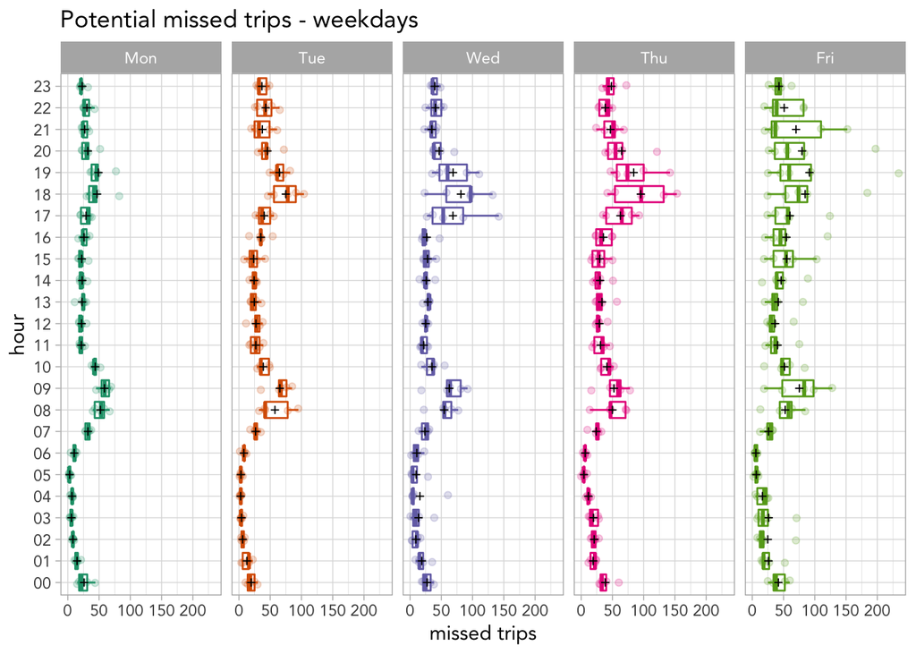

```r
demand = read.csv("OverviewSearch.csv")
supply = read.csv("DriverActivity.csv")

colnames(demand) = c("date", "saw_no_car", "saw_car", "coverage_ratio")
colnames(supply) = c("date", "active", "online", "has_booking", "waiting", "busy", "hpad",
                     "rph", "finished")

#clean data

supply <- supply %>%
  mutate(ts = paste(as.character(date), ":00:00", sep = "")) %>%
  mutate(ts = as.POSIXct(ts, format='%Y-%m-%d %H:%M:%S')) %>%
  mutate_at("date", as.character) %>%
  separate(date, c("date", "hour"), " ") %>%
  mutate(dow = wday(as.Date(date), label = TRUE))


#supply$online_adjusted = supply$has_booking + supply$waiting
#supply$percent_waiting = round(supply$waiting/supply$online_adjusted, 2)


demand <- demand %>%
  mutate(ts = paste(as.character(date), ":00:00", sep = "")) %>%
  mutate(ts = as.POSIXct(ts, format='%Y-%m-%d %H:%M:%S')) %>%
  mutate_at("date", as.character) %>%
  separate(date, c("date", "hour"), " ") %>%
  mutate(dow = wday(as.Date(date), label = TRUE))

#boxplots for weekday demand

wd = merge(x = supply, y = demand[ , c("saw_no_car", "saw_car", "ts")], by = "ts", all.x=TRUE)
wd$finished[is.na(wd$finished)] <- 0
wd$missed_trips = (wd$saw_car + wd$saw_no_car) - wd$finished

wd = wd[wd$dow %in% c("Fri","Thu","Wed","Tue","Mon"),]
neworder <- c("Mon","Tue","Wed", "Thu", "Fri")

wd <- arrange(transform(wd,
                           dow=factor(dow,levels=neworder)),dow)

wd  %>%
  ggplot(aes(x=factor(hour), y=missed_trips, color=dow)) +
  geom_boxplot(outlier.shape=NA) +
  coord_flip() +
  geom_jitter(width=0.1,alpha=0.2) +
  xlab('hour') +
  facet_wrap(~dow, ncol=5) +
  theme(axis.text.x = element_text(angle = 45, hjust = 1)) +
  scale_color_brewer(palette="Dark2") +
  theme_light()  +
  stat_summary(fun.y=mean, geom="point", shape=3, size=1, color="black")  +
  ylab("missed trips") +
  ggtitle("Potential missed trips - weekdays") +
  theme(text = element_text(family="Avenir")) +
  theme(legend.position = "none")
```

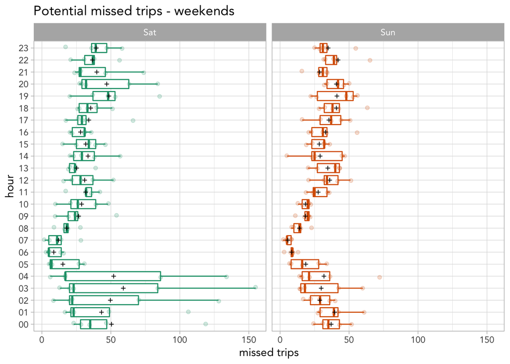

```r
we = merge(x = supply, y = demand[ , c("saw_no_car", "saw_car", "ts")], by = "ts", all.x=TRUE)
we$finished[is.na(we$finished)] <- 0
we$missed_trips = (we$saw_car + we$saw_no_car) - we$finished

we = we[we$dow %in% c("Sat", "Sun"),]

neworder <- c("Sat","Sun")

we <- arrange(transform(we,
                           dow=factor(dow,levels=neworder)),dow)

we  %>%
  ggplot(aes(x=factor(hour), y=missed_trips, color=dow)) +
  geom_boxplot(outlier.shape=NA) +
  coord_flip() +
  geom_jitter(width=0.1,alpha=0.2) +
  xlab('hour') +
  facet_wrap(~dow, ncol=5) +
  theme(axis.text.x = element_text(angle = 45, hjust = 1)) +
  scale_color_brewer(palette="Dark2") +
  theme_light()  +
  stat_summary(fun.y=mean, geom="point", shape=3, size=1, color="black")  +
  ylab("missed trips") +
  ggtitle("Potential missed trips - weekends") +
  theme(text = element_text(family="Avenir")) +
  theme(legend.position = "none")
```

#### *Even during the horus of peak demand, there are still drivers waiting around for bookings*

This observation tells us that, at peak demand periods, idle drivers should be directed to the geographical hotspots of demand in order to maximize existig supply. **Unused supply** is an important factor to consider when formulating a method to calculate undersupply. Based on a constant RPH coefficent, we are making the assumption that usused supply can be diverted to meet demand while nonexistent supply hours cannot. From here, we can devise a formula to calculate undersupply and stack rank hours of the week by their average rate of missed trips per hour.

## Real Undersupply Rate (RUR) =

## total missed trips - (waiting hours x RPH)

RUR rests on the assumption that **usused supply can be optimized to address missed trips** and that shifting supply hours should prioritize filling nonexistent supply gaps. For example, if in a given hour, there are 10 missed trips and 5 hours of waiting with RPH of 2, the **RUR = 0 trips/hour**. Compare this to 10 missed trips and 2 hours of waiting time, where **RUR = 6 trips/hour**.

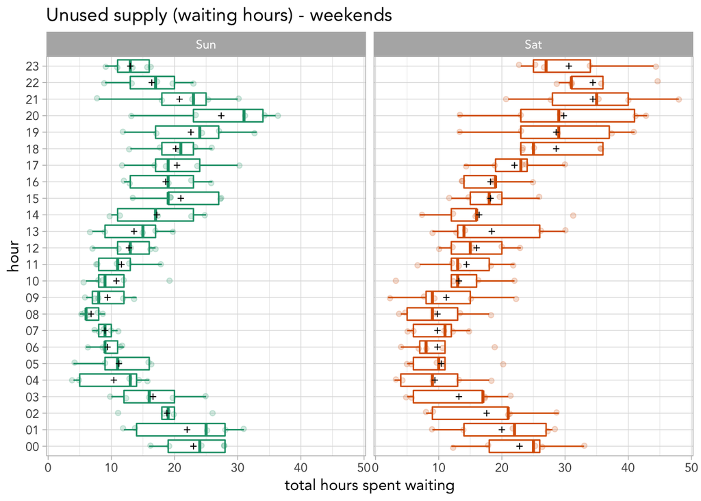

```r
wes = merge(x = supply, y = demand[ , c("saw_no_car", "saw_car", "ts")], by = "ts", all.x=TRUE)

wes = supply[supply$dow %in% c("Sun","Sat"),]

neworder <- c("Sat","Sun")
supply_copy = supply # make copy of supply data
supply <- arrange(transform(wes,
                            dow=factor(dow,levels=neworder)),dow)


wes %>%
  ggplot(aes(x=factor(hour), y=waiting, color=dow)) +
  geom_boxplot(outlier.shape=NA) +
  coord_flip() +
  geom_jitter(width=0.1,alpha=0.2) +
  xlab('hour') +
  facet_wrap(~dow, ncol=5) +
  theme(axis.text.x = element_text(angle = 45, hjust = 1)) +
  scale_color_brewer(palette="Dark2") +
  theme_light() +
  ylab("total hours spent waiting") +
  ggtitle("Unused supply (waiting hours) - weekends") +
  stat_summary(fun.y=mean, geom="point", shape=3, size=1, color="black") +
  theme(legend.position = "none") +
  theme(text = element_text(family="Avenir"))
```

We will add a column `rur` to the existing supply table and then calculate the mean RUR aggregated by weekday and hour to find the top 36 hours per week of undersupply.

```r
merged = merge(x = supply_copy, y = demand[ , c("saw_no_car", "saw_car", "ts")], by = "ts", all.x=TRUE)
merged$finished[is.na(merged$finished)] <- 0
merged$missed_trips = (merged$saw_car + merged$saw_no_car) - merged$finished
merged$rur = merged$missed_trips - (merged$rph * merged$waiting)

sample_supply = cbind(merged[2], hour(merged$ts), merged[12], merged[15], merged[10], merged[16])
colnames(sample_supply)[2] = 'hour'

ss_sorted <- head(sample_supply[order(-sample_supply$rur),])

kable(ss_sorted, row.names = F) %>%
  kable_styling("striped", full_width = F) %>%
  column_spec(6, bold = T, background = "#82E0AA")
```

| date | hour | dow | missed_trips | rph | rur |
| --- | --- | --- | --- | --- | --- |
| 2016-12-16 | 19 | Fri | 234 | 1.09 | 225.28 |
| 2016-12-16 | 20 | Fri | 197 | 1.63 | 175.81 |
| 2016-12-16 | 18 | Fri | 184 | 1.15 | 171.35 |
| 2016-12-17 | 3 | Sat | 155 | 1.76 | 146.20 |
| 2016-12-15 | 18 | Thu | 153 | 1.72 | 146.12 |
| 2016-12-15 | 19 | Thu | 142 | 1.47 | 136.12 |

Top 36 undersupplied hours sorted by RUR

```r
#top undersupplied hours

merged = merge(x = supply_copy, y = demand[ , c("saw_no_car", "saw_car", "ts")], by = "ts", all.x=TRUE)
merged$finished[is.na(merged$finished)] <- 0
merged$missed_trips = (merged$saw_car + merged$saw_no_car) - merged$finished
merged$rur = merged$missed_trips - (merged$rph * merged$waiting)

sample_supply = cbind(merged[2], hour(merged$ts), merged[12], merged[15], merged[10], merged[16])
colnames(sample_supply)[2] = 'hour'

ush = sample_supply %>%
  dplyr::group_by(hour, dow) %>%
  dplyr::summarise(mean_rur = round(mean(rur, na.rm=TRUE),1)) %>%
  dplyr::arrange(desc(mean_rur))

ush = head(ush,n=36)

kable(ush, row.names = F) %>%
  kable_styling("striped", full_width = F) %>%
  column_spec(3, bold = T, background = "#ffa343")
```

| hour | dow | mean_rur |
| --- | --- | --- |
| 18 | Thu | 82.9 |
| 19 | Fri | 76.7 |
| 18 | Fri | 72.3 |
| 19 | Thu | 69.8 |
| 18 | Wed | 68.5 |
| 9 | Fri | 65.9 |
| 20 | Fri | 63.1 |
| 18 | Tue | 61.8 |
| 17 | Wed | 56.0 |
| 21 | Fri | 53.6 |
| 9 | Tue | 53.3 |
| 19 | Wed | 52.8 |
| 9 | Wed | 50.8 |
| 17 | Thu | 50.8 |
| 3 | Sat | 49.1 |
| 20 | Thu | 49.1 |
| 19 | Tue | 48.1 |
| 9 | Mon | 48.0 |
| 8 | Tue | 47.0 |
| 16 | Fri | 46.8 |
| 15 | Fri | 46.3 |
| 17 | Fri | 46.2 |
| 8 | Wed | 45.1 |
| 4 | Sat | 44.4 |
| 8 | Fri | 43.9 |
| 8 | Mon | 43.4 |
| 10 | Fri | 42.4 |
| 9 | Thu | 40.3 |
| 8 | Thu | 40.2 |
| 14 | Fri | 38.8 |
| 2 | Sat | 38.1 |
| 10 | Mon | 34.7 |
| 19 | Mon | 34.6 |
| 13 | Fri | 34.4 |
| 0 | Sat | 34.2 |
| 22 | Fri | 33.7 |

### 2. Supply vs. demand

#### Supply

First, we want to convert supply and demand data into the same units - hours. **Supply hours** are given as **online hours**, which is the sum of hours in which drivers have bookings (any state) and hours waiting for booking. Assuming that **busy hours** cannot be converted to online hours, we will not include them on the supply side.

#### **supply hours = online hours = sum(waiting hours + hours in which drivers have bookings)**

#### Demand

Demand can be understood as the number of **potential trip hours**, or booked hours (any state) For each hour, we can assume the number of potential trips to be the sum of unique users that did see cars **and** unique users that did not see cars. A fraction of the users that did see cars made a booking and completed a trip, so *real trip hours* are by default included in potential trip hours. Again, based on the data on hand, we do not know if the same unique users are in both columns so for the purpose of this analysis, we will assume users in both columnns are unique. Therefore: **Potential trips = unique users that saw 0 cars + unique users that saw 1+ cars**. Likewise, we can find the **mean duration per booking** over the entire time period by dividing the sum of booked hours by the sum of finished trips. This is necessary to calculate potential trip hours.

**Mean duration per booking = 27.1 minutes (n = 11738)**

#### **demand hours = potenial booking hours = potential trips x mean duration per booking**

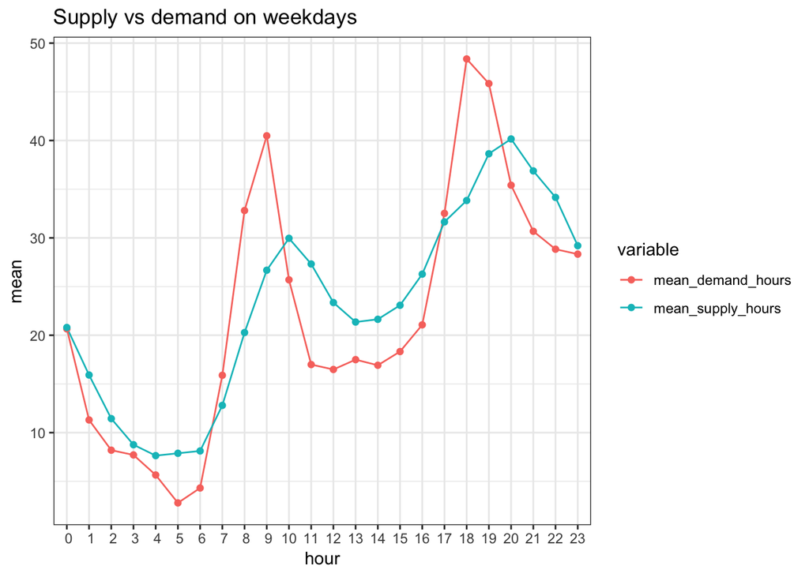

```r
## supply demand table
sd = merge(x = supply_copy, y = demand[ , c("saw_no_car", "saw_car", "ts")], by = "ts", all.x=TRUE)

sd$demand_hours = (sd$saw_car + sd$saw_no_car) *  0.4514398
sd$supply_hours = sd$online
sd$hour = hour(sd$ts)
sd$date = as.Date(sd$date)
sd$is_weekday = isWeekday(sd$date, wday=1:5)

weekend = sd[sd$is_weekday == FALSE,]


sd_weekday  =  sd %>%
    dplyr::filter(is_weekday == TRUE) %>%
    dplyr::group_by(hour) %>%
    dplyr::summarise(mean_demand_hours = mean(demand_hours, na.rm = TRUE), mean_supply_hours = mean(supply_hours))

sd_weekend =  sd %>%
    dplyr::filter(is_weekday == FALSE) %>%
    dplyr::group_by(hour) %>%
    dplyr::summarise(mean_demand_hours = mean(demand_hours, na.rm = TRUE), mean_supply_hours = mean(supply_hours))


melted_weekday = melt(sd_weekday, id='hour' )
colnames(melted_weekday) = c("hour", "variable", "mean")


ggplot(data=melted_weekday,
       aes(x=hour, y=mean, colour=variable)) +
       geom_line()  +
       geom_point()  +
    scale_x_discrete(name ="hour",
                   limits=c(0:23)) +
    ggtitle("Supply vs demand on weekdays") +
  theme_bw()
```

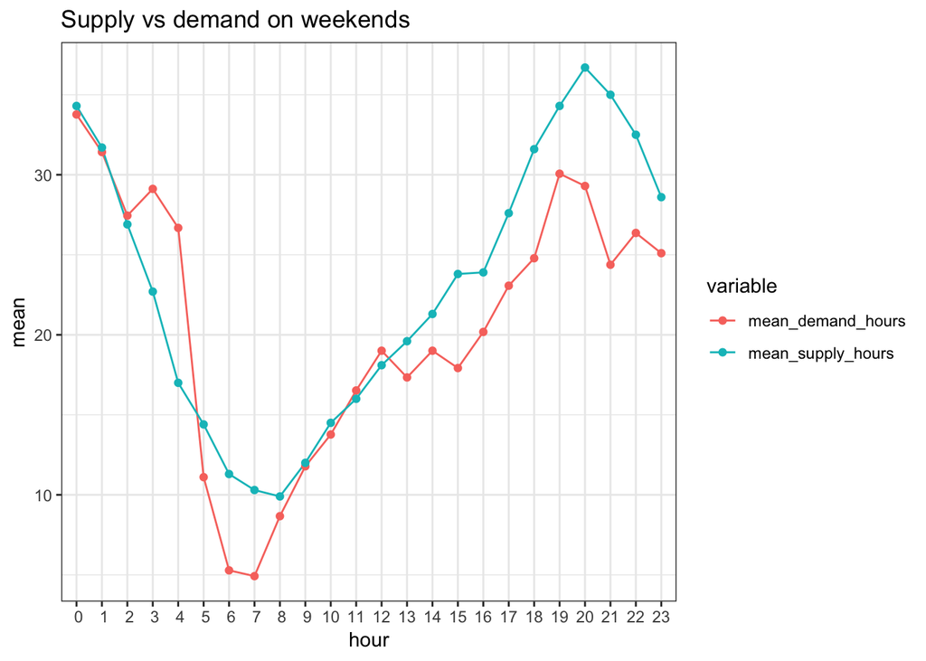

```r
melted_weekend = melt(sd_weekend, id='hour' )
colnames(melted_weekend) = c("hour", "variable", "mean")


ggplot(data=melted_weekend,
       aes(x=hour, y=mean, colour=variable)) +
       geom_line() +
       geom_point() +
   theme(text = element_text(family="Avenir")) +
    scale_x_discrete(name ="hour",
                   limits=c(0:23)) +
    ggtitle("Supply vs demand on weekends")  +
  theme_bw()
```

```r
#par(family = "Avenir")
#boxplot( (supply$has_booking * 60) / supply$finished, na.rm = TRUE, outline = F, horizontal = T, main="Distribution of booking durations", #ylab="minutes")
#points(means,1,col="red",pch=3)
#x = (supply$has_booking * 60) / supply$finished
#x = na.omit(x)
#ylim = max(density(x)$y)
#hist(x,freq=F,xlab="minutes",main="Histogram of booking duration with density curve", ylim = c(0, ylim))
#lines(density(x),lwd=3,col="red")
#rug(jitter(x),col="blue",lwd=2)
```

### 3. Visualization of undersupplied hours

The heatmap below uses the mean RUR aggregated by hour and day of week, which can be shown to drivers to guide their online time schedule.

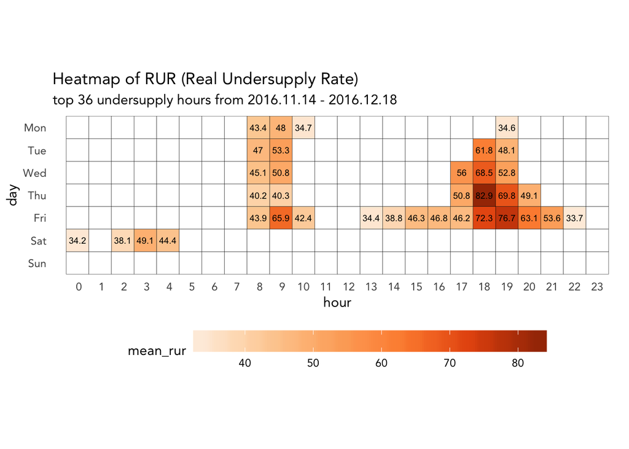

```r
merged = merge(x = supply_copy, y = demand[ , c("saw_no_car", "saw_car", "ts")], by = "ts", all.x=TRUE)
merged$finished[is.na(merged$finished)] <- 0
merged$missed_trips = (merged$saw_car + merged$saw_no_car) - merged$finished
merged$rur = merged$missed_trips - (merged$rph * merged$waiting)

sample_supply = cbind(merged[2], hour(merged$ts), merged[12], merged[15], merged[10], merged[16])
colnames(sample_supply)[2] = 'hour'

sample_supply$dow = as.character(sample_supply$dow)

#aggregate rur by hour and day of week

df2 = sample_supply %>%
  dplyr::group_by(hour, dow) %>%
  dplyr::summarise(mean_rur = mean(rur, na.rm=TRUE))

dummy = df2  #create dummy dataframe to fill with NA values

df2 = as.data.frame(head(df2[order(-df2$mean_rur),], n =36))
df2_copy = df2
df2$dow = as.character(df2$dow)
dummy$dow = as.character(dummy$dow)

diff = as.data.frame(dplyr::setdiff(dummy,df2)) # take difference between both dataframes and use diff to create NA values for heatmap
diff$mean_rur = NA

df2 = rbind(df2, diff) #combine dataframes

neworder <- c("Sun" ,"Sat", "Fri", "Thu", "Wed", "Tue", "Mon")
df2 <- arrange(transform(df2,
                         dow=factor(dow,levels=neworder)),dow)


ggplot(df2, aes(hour, dow)) +
  geom_tile(aes(fill = mean_rur), colour = "black") +
  geom_text(aes(label = round(mean_rur, 1)), na.rm = TRUE, size=2.5) +
  scale_fill_distiller(palette = "Oranges", direction = 1, na.value="white") +
  scale_x_discrete(name ="hour",
                   limits=c(0:23)) +
  theme_minimal() +
   ylab('day') +
  theme(legend.position = "bottom", legend.key.width = unit(2, "cm"),
        panel.grid = element_blank()) +
  coord_equal() +
  theme(text = element_text(family="Avenir")) +
  ggtitle("Heatmap of RUR (Real Undersupply Rate)", subtitle = "top 36 undersupply hours from 2016.11.14 - 2016.12.18 ")
```

### 4. Maintaining a high coverage ratio during peak demand

The relationship between coverage ratio and supply is not intuitive. In the plots below, we find that there is a somewhat positive relationship between online hours and coverage ratio, but the data is noisy, i.e. a high number of supply hours relative to demand does not always guarante a high coverage ratio, and a low number of supply hours relative to demand can sometimes result in high coverage. This phenomenon may be due to a tendency of available drivers to cluster in certain areas that are far from hotspots of demand, or a geographically dispersed demand pattern. It appears that different variations of supply (active drivers, online hours, supply/demand ratio) serve as a **poor predictor of coverage** [See plots below].

The sample mean coverage ratio of the top undersupplied hours is close to the population mean of all hours (72.5% and 75.6% respectively) and the medians are also not far apart (74.5% and 80%). What this tells us is that an **additional strategy** should be used in order to improve coverage rather than simply increasing supply hours to match demand hours. One method might be to incentivize some drivers to stay in predictable hotspots of demand, while incentivizing others to focus on more sparsely populated suburbs.

> However, if we can guarantee increased supply to be at the right location, then we would need an average of 12.8 extra supply hours to capture missed coverage (app opens with 0 cars) during each of the peak 36 hours of demand (for more details, see A and B on question 5).

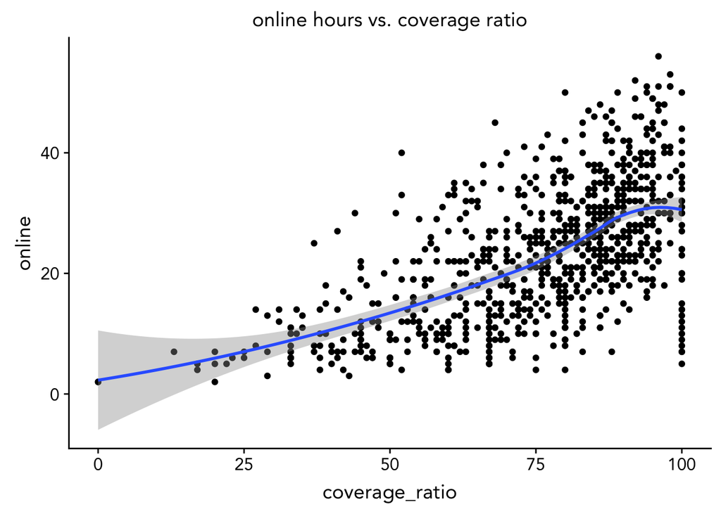

```r
sd = merge(x = supply_copy, y = demand[ , c("saw_no_car", "saw_car","coverage_ratio","ts")], by = "ts", all.x=TRUE)

sd$demand_hours = (sd$saw_car + sd$saw_no_car) *  0.4514398
sd$supply_hours = sd$online
sd$sd = sd$supply_hours - sd$demand_hours
sd$supply_demand_ratio =  sd$supply_hours/sd$demand_hours

p = ggplot(sd, aes(coverage_ratio, online)) + geom_point()  + geom_smooth(method = "loess")
p + ggtitle("online hours vs. coverage ratio") +
  theme(text = element_text(family="Avenir"))
```

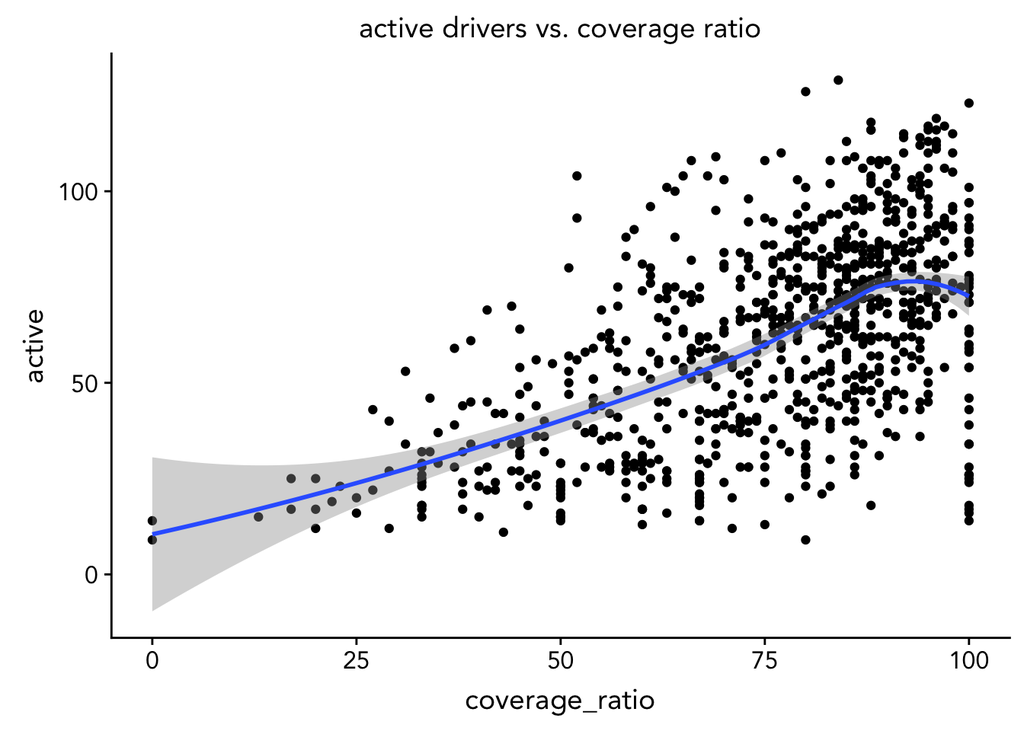

```r
p = ggplot(sd, aes(coverage_ratio, active)) + geom_point()  + geom_smooth(method = "loess")
p + ggtitle("active drivers vs. coverage ratio") +
  theme(text = element_text(family="Avenir"))
```

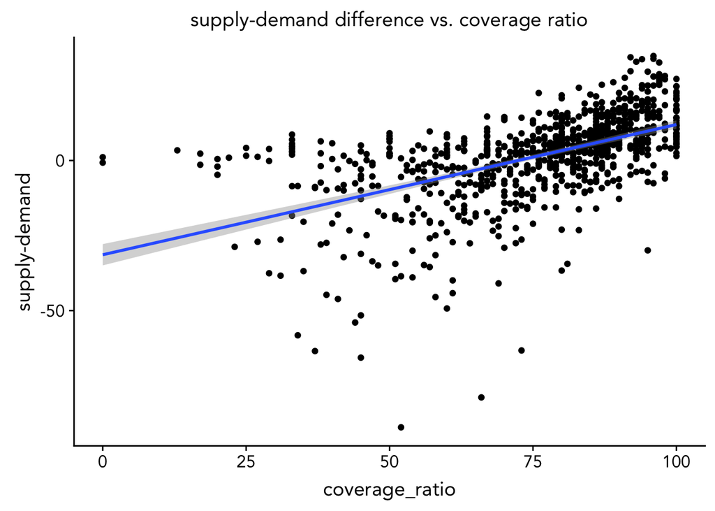

```r
p = ggplot(sd, aes(coverage_ratio, sd)) + geom_point()  + geom_smooth(method = "lm")
p + ggtitle("supply-demand difference vs. coverage ratio") +
  theme(text = element_text(family="Avenir"))  +
  ylab("supply-demand")
```

```r
sd$dow = as.character(sd$dow)
sd$hour = as.integer(hour(sd$ts))


peak_ratios = merge(x = df2_copy, y = sd[ , c("coverage_ratio", "sd", "hour", "dow")], by.x = c("hour", "dow"), by.y=c("hour", "dow"), all.x=TRUE)


ninety = sd[sd$coverage_ratio > 90,]
eighty = sd[sd$coverage_ratio > 80,]


less_than_zero = sd[sd$sd <0,]

more_than_zero = sd[sd$sd >0,]
```

### 5. Maintaining a high coverage ratio during peak demand

Since **demand** is based on app opens (unique users looking for cars), it should be noted that the top 36 hours of average demand differ slightly from the top 36 hours of undersupply. See plot below.

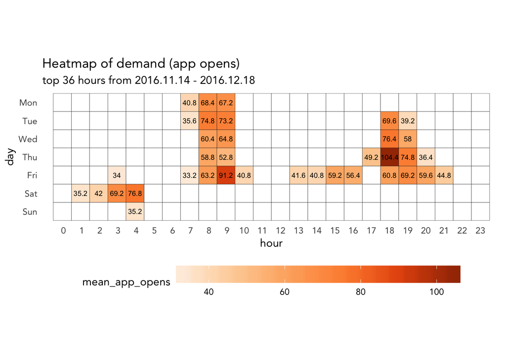

```r
demand = merge(x = supply_copy, y = demand[ , c("saw_no_car", "saw_car", "ts")], by = "ts", all.x=TRUE)
demand$app_opens = demand$saw_no_car + demand$saw_no_car


df2 = demand %>%
  dplyr::group_by(hour, dow) %>%
  dplyr::summarise(mean_app_opens = mean(app_opens, na.rm=TRUE))

dummy = df2

df2 = as.data.frame(head(df2[order(-df2$mean_app_opens),], n =36))
df2_copy = df2
df2$dow = as.character(df2$dow)
dummy$dow = as.character(dummy$dow)

diff = as.data.frame(dplyr::setdiff(dummy,df2)) # take difference between both dataframes and use diff to create NA values for heatmap
diff$mean_app_opens = NA

df2 = rbind(df2, diff) #combine dataframes

neworder <- c("Sun" ,"Sat", "Fri", "Thu", "Wed", "Tue", "Mon")

df2 <- arrange(transform(df2,
                         dow=factor(dow,levels=neworder)),dow)

df2$hour = as.integer(df2$hour)

ggplot(df2, aes(hour, dow)) +
  geom_tile(aes(fill = mean_app_opens), colour = "black") +
  geom_text(aes(label = round(mean_app_opens, 1)), na.rm = TRUE, size=2.5) +
  scale_fill_distiller(palette = "Oranges", direction = 1, na.value="white") +
  scale_x_discrete(name ="hour",
                   limits=c(0:23)) +
  theme_minimal() +
  ylab('day') +
  theme(legend.position = "bottom", legend.key.width = unit(2, "cm"),
        panel.grid = element_blank()) +
  coord_equal() +
  theme(text = element_text(family="Avenir")) +
  ggtitle("Heatmap of demand (app opens)", subtitle = "top 36 hours from 2016.11.14 - 2016.12.18 ")
```

For RPH, we will take the `lead` and `lag` values to calculate a 3-hour average RPH, which will then be aggreagaed by day and hour for the 36 hours with highest demand. For example:

```r
demand = merge(x = supply_copy, y = demand[ , c("saw_no_car", "saw_car", "ts")], by = "ts", all.x=TRUE)
demand$app_opens = demand$saw_no_car + demand$saw_no_car

demand = demand %>%  mutate(lag_rph = lag(rph, order_by = ts), lead_rph = lead(rph, order_by = ts) )
demand$moving_avg_rph = round((demand$rph + demand$lag_rph + demand$lead_rph) / 3,2)

tbl = head(cbind(demand[1], demand[15], demand[10], demand[16], demand[17], demand[18]), n=10)[5:10,]

kable(tbl, row.names = F) %>%
  kable_styling("striped", full_width = F) %>%
  column_spec(6, bold = T, background = "#ffa343")
```

| ts | app_opens | rph | lag_rph | lead_rph | moving_avg_rph |
| --- | --- | --- | --- | --- | --- |
| 2016-11-14 04:00:00 | 8 | 0.00 | 0.00 | 0.50 | 0.17 |
| 2016-11-14 05:00:00 | 8 | 0.50 | 0.00 | 0.14 | 0.21 |
| 2016-11-14 06:00:00 | 2 | 0.14 | 0.50 | 1.11 | 0.58 |
| 2016-11-14 07:00:00 | 44 | 1.11 | 0.14 | 1.19 | 0.81 |
| 2016-11-14 08:00:00 | 76 | 1.19 | 1.11 | 0.95 | 1.08 |
| 2016-11-14 09:00:00 | 86 | 0.95 | 1.19 | 0.54 | 0.89 |

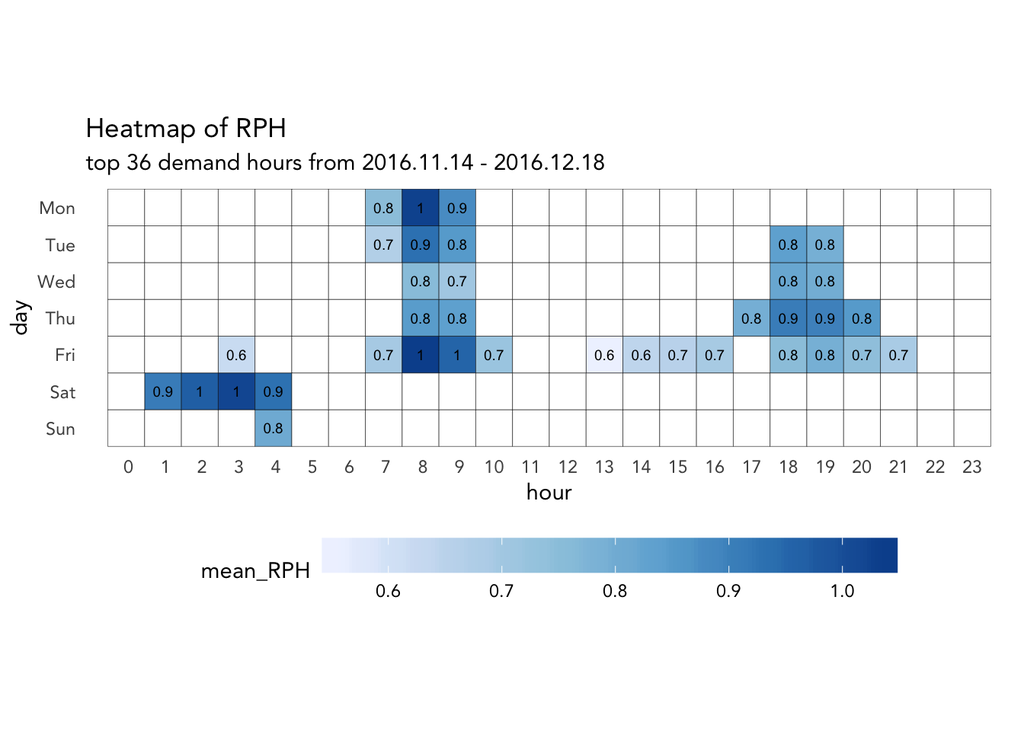

```r
peak_demand = merge(x = df2_copy, y = demand[ , c("moving_avg_rph", "hour", "dow", "saw_no_car")], by.x = c("hour", "dow"))

peak_demand = peak_demand %>%
  dplyr::group_by(hour, dow) %>%
  dplyr::summarise(mean_RPH = mean(moving_avg_rph))

#mean(peak_demand$mean_RPH)
#range(peak_demand$mean_RPH)

peak_demand$hour = as.integer(peak_demand$hour)


a = as.data.frame(peak_demand)
b = diff
colnames(b) = c("hour", "dow", "mean_RPH")
test = rbind(a,b)
test$hour = as.integer(test$hour)


neworder <- c("Sun" ,"Sat", "Fri", "Thu", "Wed", "Tue", "Mon")
test <- arrange(transform(test,
                         dow=factor(dow,levels=neworder)),dow)


ggplot(test, aes(hour, dow)) +
  geom_tile(aes(fill = mean_RPH), colour = "black") +
  geom_text(aes(label = round(mean_RPH, 1)), na.rm = TRUE, size=2.5) +
  scale_fill_distiller(palette = "Blues", direction = 1, na.value="white") +
  scale_x_discrete(name ="hour",
                   limits=c(0:23)) +
  theme_minimal() +
  theme(legend.position = "bottom", legend.key.width = unit(2, "cm"),
        panel.grid = element_blank()) +
  coord_equal() +
  ylab('day') +
  theme(text = element_text(family="Avenir")) +
  ggtitle("Heatmap of RPH", subtitle = "top 36 demand hours from 2016.11.14 - 2016.12.18 ")
```

#### A. Mean rate of app opens where user saw no cars across 36 peak demand hours was 28.5 per hour

- *Assuming that each of these app opens will convert to a booking with increased supply, then we would need to multiply this rate by the mean duration per booking (27.1 minutes or 0.45 hours) to get the extra supply hours needed to cover them.*

#### B. An average of 12.8 extra supply hours will be needed to service each hour during the peak 36 hours of demand.

- *Assuming that demand remains constant with increased supply, we can also assume that the RPH values above will remain constant. That's because the denominator of RPH - online hours - will increase, but so will the numerator - volume of trips.*

#### C. Mean RPH (using 3-hour period average of current, lead, and lag hour) across the 36 peak demand hours = 0.81 RPH with a range of 0..55 - 1.04 RPH

- *Given a constant RPH of 0.81, we can assume that each driver will complete an averge of 0.81 trips per hour during the peak periods of demand.*

> Assuming that incresed supply will capture missed coverage (app opens with 0 cars), and based on an average trip fare of 10 EUR with an 80/20 split in revenue, we can therefore guarantee a base hourly income of 8 EUR x 0.81 RPH = 6.48 EUR per hour without paying out extra to drivers and keeping our 20% cut. ***

## High level recommendations:

> We know from the supply demand curves that supply does not match demand depending on the day.

| Day type | oversupply | undersupply |
| --- | --- | --- |
| weekday | 1-6, 10-16, 20-22 | 7-9, 17-19 |
| weekend | 13-23, 5-8 | 2-4 |

> Oversupplied hours can be shifted to undersupplied hours using the heatmap below, which shows the top 36 demand-supply imbalances in either direction from the perspective of no coverage (# of users that saw no car (potential trips) - (waiting hours x RPH)). Simply by shifting all of the idle driver hours from negative squares to positive squares, we would put idle time to good use by fulfilling 41% of the potential trips from no coverage at peak hours.

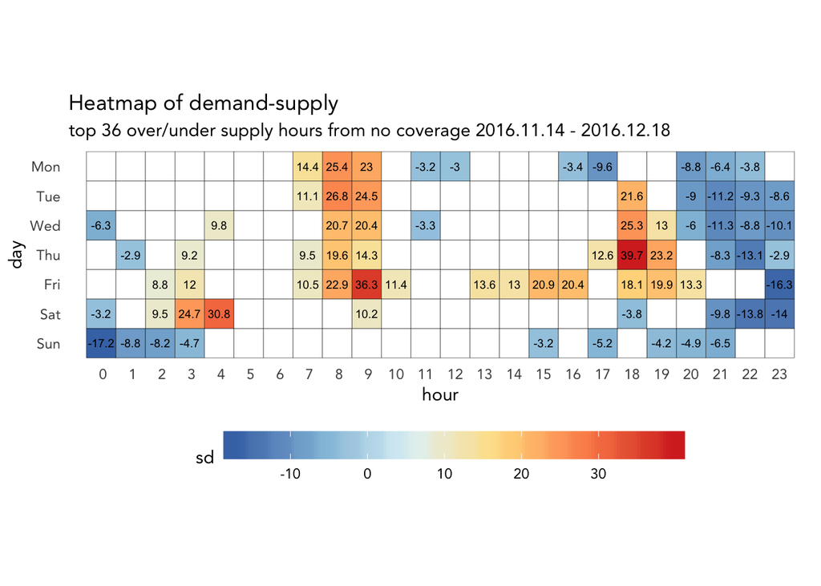

```r
merged = merge(x = supply_copy, y = demand[ , c("saw_no_car", "saw_car", "ts")], by = "ts", all.x=TRUE)
merged$finished[is.na(merged$finished)] <- 0
merged$missed_trips = (merged$saw_no_car)
merged$sd = merged$missed_trips - (merged$rph * merged$waiting)

sample_supply = cbind(merged[2], hour(merged$ts), merged[12], merged[15], merged[10], merged[16])
colnames(sample_supply)[2] = 'hour'

sample_supply$dow = as.character(sample_supply$dow)

#aggregate rur by hour and day of week

df2 = sample_supply %>%
  dplyr::group_by(hour, dow) %>%
  dplyr::summarise(sd = mean(sd, na.rm=TRUE))

dummy = df2  #create dummy dataframe to fill with NA values

df3  = as.data.frame(head(df2[order(df2$sd),], n =36))
df2 = as.data.frame(head(df2[order(-df2$sd),], n =36))


df2$dow = as.character(df2$dow)
df3$dow = as.character(df3$dow)
dummy$dow = as.character(dummy$dow)

diff = as.data.frame(dplyr::setdiff(dummy,df2)) # take difference between both dataframes and use diff to create NA values for heatmap
diff = as.data.frame(dplyr::setdiff(diff,df3))

diff$sd = NA

df2 = rbind(df2, df3)
df2 = rbind(df2, diff)
#combine dataframes

neworder <- c("Sun" ,"Sat", "Fri", "Thu", "Wed", "Tue", "Mon")
df2 <- arrange(transform(df2,
                         dow=factor(dow,levels=neworder)),dow)


ggplot(df2, aes(hour, dow)) +
  geom_tile(aes(fill = sd), colour = "black") +
  geom_text(aes(label = round(sd, 1)), na.rm = TRUE, size=2.5) +
  scale_fill_distiller(palette = "RdYlBu", direction = -1, na.value="white") +
  scale_x_discrete(name ="hour",
                   limits=c(0:23)) +
  theme_minimal() +
   ylab('day') +
  theme(legend.position = "bottom", legend.key.width = unit(2, "cm"),
        panel.grid = element_blank()) +
  coord_equal() +
  theme(text = element_text(family="Avenir")) +
  ggtitle("Heatmap of demand-supply", subtitle = "top 36 over/under supply hours from no coverage 2016.11.14 - 2016.12.18 ")
```